# Your Digest for Tuesday, Sep 05, 2023 11:59 PM

## Other hormones regulating blood glucose level

#2021BSQ-NOV Q07

- Catecholamines increase hepatic glucose output;
- Epinephrine (adrenaline) decreases peripheral uptake of glucose.
  - provides anti-insulin action.
  - Important in type 1 diabetics because they lose the ability to secrete glucagon as well! (protects them against hypoglycaemia)
- Thyroxine: hyperthyroidism exacerbates diabetes. Thyroxine increases gut absorption of glucose and potentiate catecholamine action (which is as above)
- Glucocorticoids: Have a permissive effect on the actions of glucagon and attenuating action on insulin.
  - They are necessary for glucagon mediated gluconeogenesis during fasting.
  - Hypoglycaemic effect of insulin is much stronger (even too strong!) in the absence of glucocorticoids.
  - Both effects above cause hypoglycaemia seen in Addison's disease.
  - The diabetogenic effects are due to increase in protein catabolism, increased gluconeogenesis and decreased peripheral utilization of blucose.
- Exercise: not a hormone BUT
  - Exercise causes upregulation of **GLUT-4** transported in muscle and this causes insulin *independent* increase in glucose uptake.

## Glucose transporters

> [!TIP] Mnemonic  
> GLUT-2 and GLUT-4 : even numbered ones are involved in insulin mediated glucose regulation.  
> 1 and 3 are basal, non insulin dependent transporters.

| Transporter | Site |
| --- | --- |
| SGLT-1 | small intestine and renal tubules |
| SGLT-2 | renal tubules |
| GLUT 1,3 | basal glucose uptake 'everywhere' |
| GLUT 2 | beta cell glucose sensor |
| GLUT 4 | insulin mediated glucose uptake in Sk and cardiac muscle, adipocytes |
| GLUT 5 | Fructose transporter |

# Adrenaline synthesis

> [!TIP] Mnemonic  
> Dopamine -> Norad -> adrenaline -> ?waste products

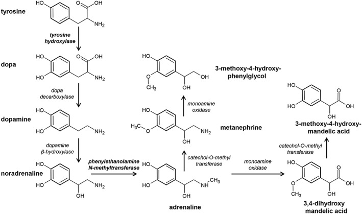

[figure not shown]

- Ticagrelor produces non-competitive reversible inhibition.

# Dead space Vs. Shunts in the lung

[Source - very detailed article](https://erj.ersjournals.com/content/44/4/1023#sec-4)  
[A reddit post](https://www.reddit.com/r/medicalschoolanki/comments/odm5ab/can_anyone_explain_why_dead_space_and_shunting/)

> [!INFO] The only 5 causes of hypoxaemia!  
> There are only 5 causes of hypoxaemia:  
> Note: **Dead space** is *NOT* a cause for hypoxaemia

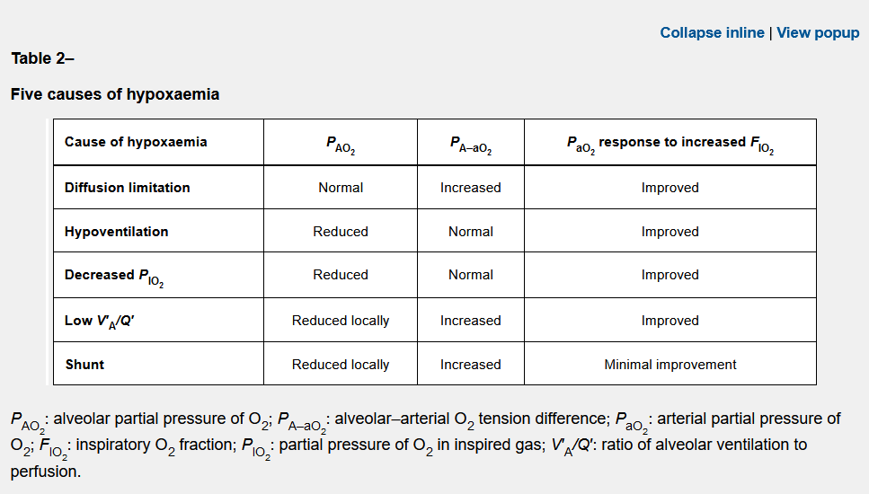

> [!INFO] **Shunt**

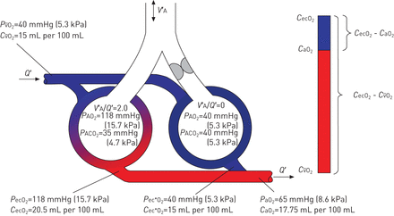

> [!INFO] **Deadspace**

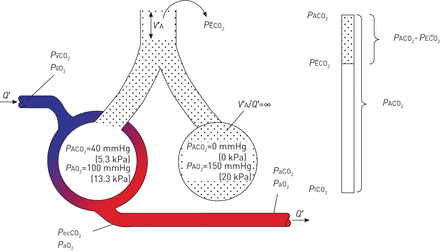

## Theory and equations

[Source](https://www.ncbi.nlm.nih.gov/books/NBK545153/)

> [!INFO] **Definition**
> Difference in oxygen concentration between the alveoli and the arterial system.
> $$
> A-a\space gradient = PAO_2 - PaO_2
> $$
> A - alveolar, a - arterial.

But how do we know what the PAO2 is? Well it's estimated using the **alveolar gas equation.**

> [!INFO] Alveolar gas equation
> $$
> PAO_2 = (P_atm - P_H2O) FiO_2 - PaCO_2/RQ
> $$
> RQ = respiratory quotient. Varies depending on which substrate is being used for aerobic respiration (i.e carbs vs. fats etc).
> RQ = amount of CO2 produced / amount of oxygen consumed.

The alveolar gas equations shows us the main parameters which affect alveolar PO2. (PAO2)

**The main variables quantities in the alveolar gas equation are**

1. Atmospheric pressure
2. FiO2
3. Levels of CO2.

> [!INFO]  
> Theoretically, there the A-a gradient should be zero as oxygen should equilibriate between alveoli and the capillaries.  
> But in reality, an A-a gradient arises because of non uniformity of V/Q ratios throughout the lung.